# **Project : Employee Sentiment Analysis**

Name: Shaidatullisa Nadia Binti Saipudin

## Introduction

This project focuses on understanding how employees feel based on the messages they send (like emails or internal communications). The goal is to find out which employees are happy, frustrated, or neutral in their communication, and how their mood changes over time.

The process is divided into 6 tasks:

- Label each message with a sentiment (Positive, Negative, Neutral).
- Explore the data to find patterns and problems
- Calculate how employees feel each month.
- Rank the happiest and most upset employees.
- Spot employees who may be at risk of quitting.
- Build a model that predicts how sentiment might change

```python
# Load Required Libraries
import pandas as pd
from transformers import pipeline
import matplotlib.pyplot as plt
import pandas as pd
import seaborn as sns

# Load and Prepare Dataset
df = pd.read_csv("test.csv")

# Convert 'date' to datetime format
df['date'] = pd.to_datetime(df['date'], errors='coerce')

# Extract 'month' for later tasks
df['month'] = df['date'].dt.to_period('M')
```

### **Task 1: Sentiment Labeling**

### **Approach Used:**

- Used a **hybrid method** combining keyword rules and a transformer model for sentiment classification.
- Labeled messages as **Positive**, **Negative**, or **Neutral**.

### **Steps Taken:**

- Loaded the dataset and parsed dates.
- Created a `month` column for later use.
- Defined custom **positive and negative keyword lists**.
- Initialized a **sentiment analysis pipeline** using Hugging Face Transformers.
- Built a function to:
  - First check keywords.
  - If no match, use the model with a confidence threshold.
- Applied the function to the message column.
- Saved the output with sentiment labels.

### **Why This Works:**

- Combines fast, clear **keyword logic** with **model-based interpretation** for better accuracy.
- Reduces misclassification by using a **confidence filter**.
- Covers both rule-based and contextual sentiment detection.

```python
# Define Keyword Lists (Employee context)

# Positive Keywords
positive_keywords = [
    "appreciate", "thanks", "thank you", "great job", "well done", "pleased",
    "awesome", "happy", "glad", "good work", "excellent", "fantastic", "love",
    "impressed", "smooth process", "resolved", "completed successfully",
    "grateful", "team effort", "productive", "celebrated", "promotion"
]

# Negative Keywords
negative_keywords = [
    "disappointed", "frustrated", "angry", "upset", "bad", "poor", "hate", "unhappy",
    "issue", "problem", "delay", "complaint", "concern", "dissatisfied", "escalate",
    "unable to", "missed deadline", "error", "not working", "termination", "layoff",
    "conflict", "resign", "quitting", "disciplinary", "reprimand"
]

# Load Sentiment Model (Transformers Pipeline)
sentiment_pipeline = pipeline(
    "sentiment-analysis",
    model="distilbert-base-uncased-finetuned-sst-2-english"
)

# Define Hybrid Sentiment Classifier
def classify_sentiment(text, model_threshold=0.75):
    if pd.isnull(text) or str(text).strip() == '':
        return "Neutral"

    text_lower = str(text).lower()

    contains_pos = any(kw in text_lower for kw in positive_keywords)
    contains_neg = any(kw in text_lower for kw in negative_keywords)

    # Case: Both types of keywords found
    if contains_pos and contains_neg:
        return "Neutral"
    elif contains_neg:
        return "Negative"
    elif contains_pos:
        return "Positive"

    # Use LLM fallback if keywords don't match
    model_result = sentiment_pipeline(text[:512])[0]
    label = model_result['label']
    score = model_result['score']

    # Confidence-based sentiment interpretation
    if label == "POSITIVE" and score >= model_threshold:
        return "Positive"
    elif label == "NEGATIVE" and score >= model_threshold:
        return "Negative"
    else:
        return "Neutral"

# Apply Sentiment Classification
df['Final_sentiment'] = df['body'].apply(classify_sentiment)

# Preview
print(df[['from', 'date', 'body', 'Final_sentiment']].head())

# Save Result
df.to_csv("Final_sentiment.csv", index=False)
```

```
Device set to use cpu
```

```
                      from       date  \
0     sally.beck@enron.com 2010-05-10
1      eric.bass@enron.com 2010-07-29
2     sally.beck@enron.com 2011-07-25
3  johnny.palmer@enron.com 2010-03-25
4  lydia.delgado@enron.com 2011-05-21

                                                body Final_sentiment
0  EnronOptions Announcement\n\n\nWe have updated...        Negative
1  Marc,\n\nUnfortunately, today is not going to ...        Positive
2  When: Wednesday, June 06, 2001 10:00 AM-11:00 ...         Neutral
3  we were thinking papasitos (we can meet somewh...        Negative
4  Since you never gave me the $20 for the last t...        Positive
```

```python
# Make a copy of the labeled DataFrame
df_labeled = df.copy()
```

### **Task 2: EDA Summary**

**What I did:**

- Merged and analyzed the labeled sentiment data (`Final_sentiment`) from Task 1.
- Checked the dataset structure, missing values, and message volumes.
- Analyzed sentiment **distribution** and **monthly trends** by sentiment.
- Explored employee-level sentiment ratios and top senders with high negative rates.
- Created a **7-day rolling sentiment trend** to catch short-term stress or engagement drops.

[output not shown]

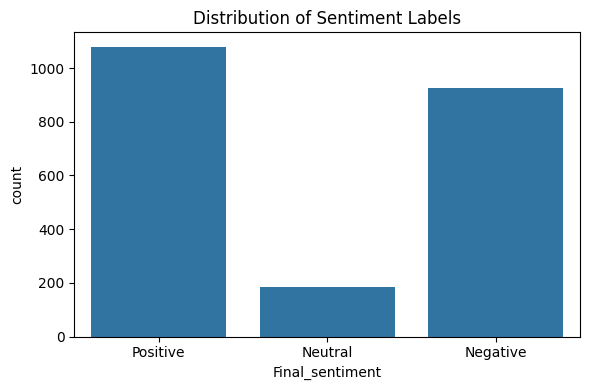

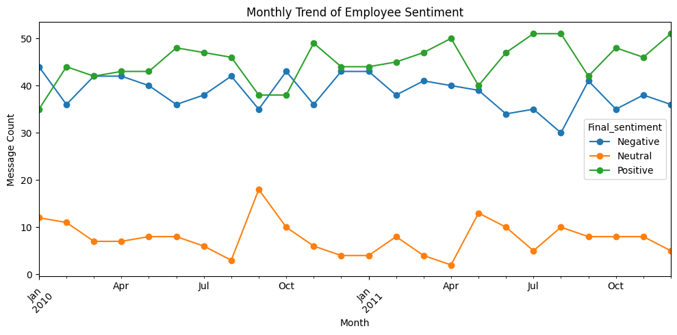

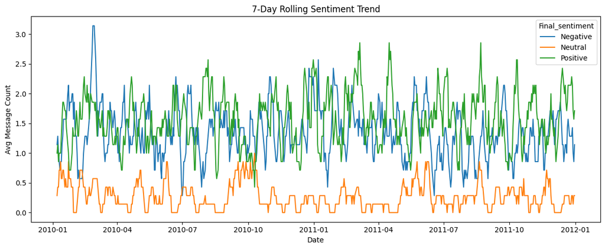

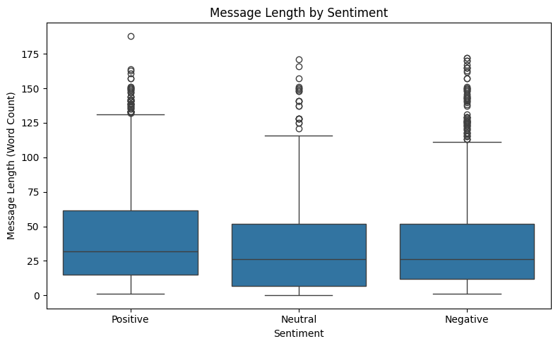

```
Final_sentiment              Negative   Neutral  Positive  Total_Messages
from
rhonda.denton@enron.com      0.476744  0.034884  0.488372             172
kayne.coulter@enron.com      0.465517  0.086207  0.448276             174
bobette.riner@ipgdirect.com  0.460829  0.082949  0.456221             217
don.baughman@enron.com       0.446009  0.117371  0.436620             213
patti.thompson@enron.com     0.444444  0.075556  0.480000             225
john.arnold@enron.com        0.425781  0.097656  0.476562             256
eric.bass@enron.com          0.409524  0.090476  0.500000             210
sally.beck@enron.com         0.387665  0.083700  0.528634             227
lydia.delgado@enron.com      0.383803  0.077465  0.538732             284
johnny.palmer@enron.com      0.361502  0.089202  0.549296             213
                             Total_Messages  Negative_Messages  Negative_Rate
from
lydia.delgado@enron.com                 284                109       0.383803
john.arnold@enron.com                   256                109       0.425781
sally.beck@enron.com                    227                 88       0.387665
patti.thompson@enron.com                225                100       0.444444
bobette.riner@ipgdirect.com             217                100       0.460829
don.baughman@enron.com                  213                 95       0.446009
johnny.palmer@enron.com                 213                 77       0.361502
eric.bass@enron.com                     210                 86       0.409524
kayne.coulter@enron.com                 174                 81       0.465517
rhonda.denton@enron.com                 172                 82       0.476744
```

```python
# Convert 'date' to datetime
df_labeled["date"] = pd.to_datetime(df_labeled["date"], errors="coerce")
df_labeled["year_month"] = df_labeled["date"].dt.to_period("M")
df_labeled["day"] = df_labeled["date"].dt.date
df_labeled["month"] = df_labeled["date"].dt.to_period("M")
df_labeled["message_length"] = df_labeled["body"].apply(lambda x: len(str(x).split()))

# Dataset Structure Summary
structure_summary = pd.DataFrame({
    "Column": df_labeled.columns,
    "Data Type": df_labeled.dtypes.values,
    "Missing Values": df_labeled.isnull().sum().values,
    "Unique Values": df_labeled.nunique().values
})
print(structure_summary)

# Sentiment Distribution
plt.figure(figsize=(6, 4))
sns.countplot(data=df_labeled, x="Final_sentiment", order=["Positive", "Neutral", "Negative"])
plt.title("Distribution of Sentiment Labels")
plt.tight_layout()
plt.show()

# Monthly Sentiment Trends
monthly_trends = df_labeled.groupby(["year_month", "Final_sentiment"]).size().unstack().fillna(0)
monthly_trends.plot(kind="line", marker="o", figsize=(10, 5), title="Monthly Trend of Employee Sentiment")
plt.xlabel("Month")
plt.ylabel("Message Count")
plt.xticks(rotation=45)
plt.tight_layout()
plt.show()

# Weekly Rolling Sentiment Trend
daily_trend = df_labeled.groupby(["day", "Final_sentiment"]).size().unstack().fillna(0)
rolling_trend = daily_trend.rolling(window=7).mean()
rolling_trend.plot(figsize=(12, 5), title="7-Day Rolling Sentiment Trend")
plt.xlabel("Date")
plt.ylabel("Avg Message Count")
plt.tight_layout()
plt.show()

# Message Length Distribution by Sentiment
plt.figure(figsize=(8, 5))
sns.boxplot(data=df_labeled, x="Final_sentiment", y="message_length", order=["Positive", "Neutral", "Negative"])
plt.title("Message Length by Sentiment")
plt.xlabel("Sentiment")
plt.ylabel("Message Length (Word Count)")
plt.tight_layout()
plt.show()

# Sentiment Ratio per Employee
sentiment_ratio = df_labeled.groupby("from")["Final_sentiment"].value_counts(normalize=True).unstack().fillna(0)
sentiment_ratio["Total_Messages"] = df_labeled["from"].value_counts()
sentiment_ratio_sorted = sentiment_ratio.sort_values(by="Negative", ascending=False)
print(sentiment_ratio_sorted.head(10))

# Top Senders by Volume and Negative Rate
sender_volume = df_labeled["from"].value_counts().rename("Total_Messages")
negative_count = df_labeled[df_labeled["Final_sentiment"] == "Negative"]["from"].value_counts().rename("Negative_Messages")
top_senders = pd.concat([sender_volume, negative_count], axis=1).fillna(0)
top_senders["Negative_Rate"] = top_senders["Negative_Messages"] / top_senders["Total_Messages"]
top_senders_sorted = top_senders.sort_values(by="Total_Messages", ascending=False)
print(top_senders_sorted.head(10))
```

### **Task 3: Employee Score Calculation**

**What I did:**

- Assigned each message a numeric score:
  - **+1** for Positive
  - **0** for Neutral
  - **–1** for Negative
- Grouped all messages by **employee** and **month**.
- Calculated the **total sentiment score** for each employee per month by summing the message scores.
- Saved the results in a new dataset called `monthly_employee_sentiment_scores.csv`.

**Why this matters:**

- The monthly score reflects an employee’s **sentiment trend over time**.
- Scores reset each month to ensure **accurate tracking** of engagement changes.
- This data forms the foundation for the next steps: **ranking top/bottom performers** and identifying **flight risks** based on prolonged negativity.

```python
# Map sentiment labels to numeric scores
score_map = {"Positive": 1, "Negative": -1, "Neutral": 0}
df_labeled["sentiment_score"] = df_labeled["Final_sentiment"].map(score_map)

# Group by employee and month, then sum the sentiment scores
monthly_employee_scores = df_labeled.groupby(["from", "month"])["sentiment_score"].sum().reset_index()

# Rename columns for clarity
monthly_employee_scores.rename(columns={
    "from": "employee",
    "month": "month",
    "sentiment_score": "monthly_sentiment_score"
}, inplace=True)

# Save to CSV file
monthly_employee_scores.to_csv("monthly_employee_sentiment_scores.csv", index=False)

# Preview the output
print("Monthly employee sentiment scores")
print(monthly_employee_scores.head(15))
```

```
Monthly employee sentiment scores
                       employee    month  monthly_sentiment_score
0   bobette.riner@ipgdirect.com  2010-01                       -2
1   bobette.riner@ipgdirect.com  2010-02                        3
2   bobette.riner@ipgdirect.com  2010-03                        0
3   bobette.riner@ipgdirect.com  2010-04                       -2
4   bobette.riner@ipgdirect.com  2010-05                        1
5   bobette.riner@ipgdirect.com  2010-06                        0
6   bobette.riner@ipgdirect.com  2010-07                        2
7   bobette.riner@ipgdirect.com  2010-08                       -6
8   bobette.riner@ipgdirect.com  2010-09                        3
9   bobette.riner@ipgdirect.com  2010-10                        4
10  bobette.riner@ipgdirect.com  2010-11                        4
11  bobette.riner@ipgdirect.com  2010-12                        0
12  bobette.riner@ipgdirect.com  2011-01                       -2
13  bobette.riner@ipgdirect.com  2011-02                       -3
14  bobette.riner@ipgdirect.com  2011-03                        1
```

### **Task 4: Employee Ranking**

**What I did:**

- Loaded the monthly sentiment scores from a CSV file containing each employee's aggregated sentiment score by month.
- Converted the `month` column to a `Period` format to ensure proper monthly grouping and time-based sorting.
- Sorted the data by month and sentiment score to identify the top 3 employees with the highest (positive) and lowest (negative) sentiment scores per month.
- Combined both rankings into a single dataset and filtered it to visualize results for **only the latest month**.
- Created two separate bar charts: one for the top 3 positive employees and another for the top 3 negative employees in that selected month.
- Exported the filtered monthly ranking data as `top_3_employees_single_month.csv` for reporting purposes.

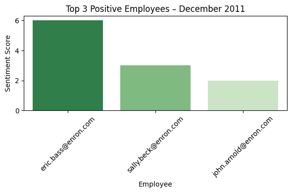

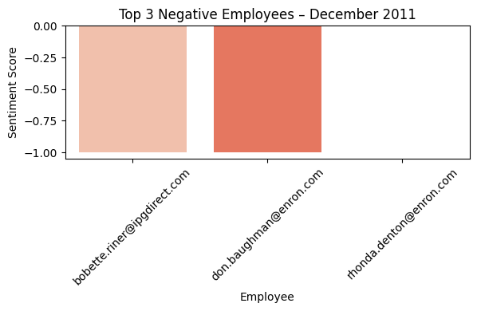

```python
# Load csv
monthly_employee_scores = pd.read_csv("/content/monthly_employee_sentiment_scores.csv")  # ensure it includes 'month', 'employee', 'monthly_sentiment_score'

# Convert 'month' column back to Period type after loading from CSV
# Use 'M' for month frequency, consistent with previous usage
monthly_employee_scores['month'] = pd.PeriodIndex(monthly_employee_scores['month'], freq='M')


# Identify Top 3 Positive and Negative Employees PER MONTH
top_positive = (
    monthly_employee_scores
    .sort_values(by=["month", "monthly_sentiment_score", "employee"], ascending=[True, False, True])
    .groupby("month", group_keys=False)
    .head(3)
    .assign(RankType="Top Positive")
)

top_negative = (
    monthly_employee_scores
    .sort_values(by=["month", "monthly_sentiment_score", "employee"], ascending=[True, True, True])
    .groupby("month", group_keys=False)
    .head(3)
    .assign(RankType="Top Negative")
)

# Combine
monthly_top = pd.concat([top_positive, top_negative]).sort_values(by=["month", "RankType"])

# Select ONE month only (latest or specific)
latest_month = monthly_top["month"].max()  # you can replace with specific: pd.Period("2023-11")
month_data = monthly_top[monthly_top["month"] == latest_month]
# Now latest_month is a Period object, so we can access its start_time for strftime
month_str = latest_month.start_time.strftime("%B %Y")

# Split and plot
positive_data = month_data[month_data["RankType"] == "Top Positive"]
negative_data = month_data[month_data["RankType"] == "Top Negative"]

# Plot Positive
plt.figure(figsize=(6, 4))
sns.barplot(data=positive_data, x="employee", y="monthly_sentiment_score", palette="Greens_r")
plt.title(f"Top 3 Positive Employees – {month_str}")
plt.xlabel("Employee")
plt.ylabel("Sentiment Score")
plt.xticks(rotation=45)
plt.tight_layout()
plt.show()

# Plot Negative
plt.figure(figsize=(6, 4))
sns.barplot(data=negative_data, x="employee", y="monthly_sentiment_score", palette="Reds")
plt.title(f"Top 3 Negative Employees – {month_str}")
plt.xlabel("Employee")
plt.ylabel("Sentiment Score")
plt.xticks(rotation=45)
plt.tight_layout()
plt.show()

# Step 4: Export combined data table
month_data[["month", "RankType", "employee", "monthly_sentiment_score"]].to_csv("top_3_employees_single_month.csv", index=False)
```

### **Task 5: Flight Risk Identification**

**What I did:**

**Why this matters:** This task helps detect employees who show signs of **disengagement, frustration, or dissatisfaction** based on message behavior. The use of a **rolling 30-day window** ensures the detection is robust and not limited by month boundaries.

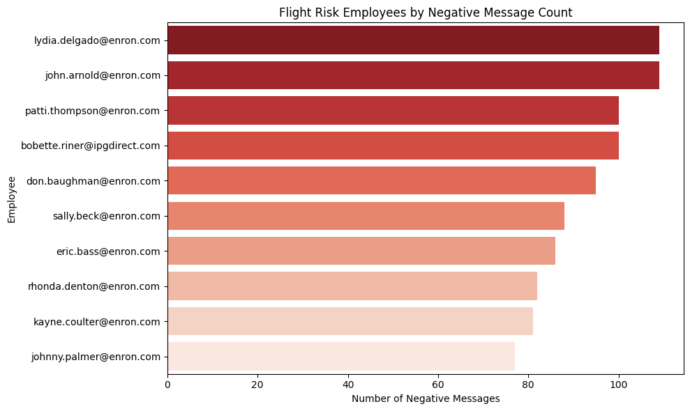

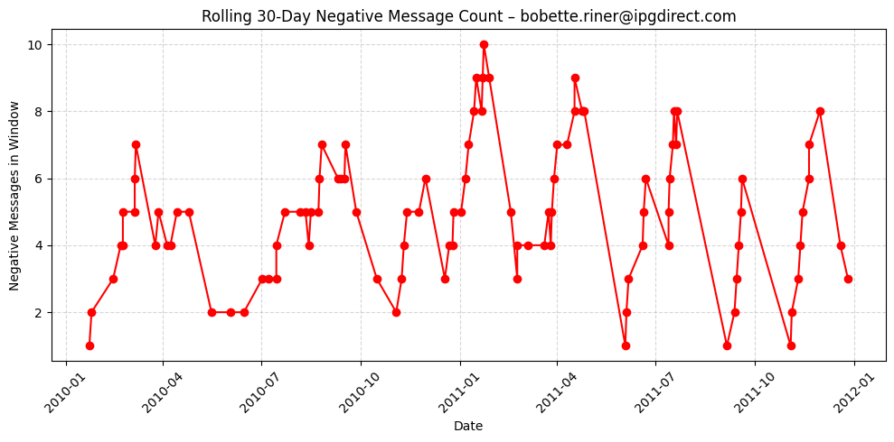

```python
# Filter only negative messages and organize
negatives_only = df_labeled[df_labeled["Final_sentiment"] == "Negative"].copy()
negatives_only["date"] = pd.to_datetime(negatives_only["date"])
negatives_only = negatives_only.sort_values(by=["from", "date"])

# Detect flight risks (4+ negative messages in any rolling 30-day window)
risk_candidates = set()

for sender in negatives_only["from"].unique():
    emp_msgs = negatives_only[negatives_only["from"] == sender].set_index("date").sort_index()
    rolling_count = emp_msgs["Final_sentiment"].rolling("30D").count()

    if (rolling_count >= 4).any():
        risk_candidates.add(sender)

# Create DataFrame of flight risk employees
flight_risk_df = pd.DataFrame({"employee": sorted(list(risk_candidates))})
#flight_risk_df.to_csv("flight_risk_employees.csv", index=False)

# Count total negative messages per flight risk employee
negative_counts = (
    negatives_only[negatives_only["from"].isin(flight_risk_df["employee"])]
    .groupby("from")["Final_sentiment"]
    .count()
    .reset_index()
    .rename(columns={"from": "employee", "Final_sentiment": "Total Negative Messages"})
    .sort_values(by="Total Negative Messages", ascending=False)
)

# Merge with flight risk list
flight_risk_detailed = pd.merge(flight_risk_df, negative_counts, on="employee")
#flight_risk_detailed.to_csv("flight_risk_detailed.csv", index=False)

# Sort by count
flight_risk_sorted = flight_risk_detailed.sort_values(by="Total Negative Messages", ascending=False)

# Plot
plt.figure(figsize=(10, 6))
sns.barplot(data=flight_risk_sorted, x="Total Negative Messages", y="employee", palette="Reds_r")
plt.title("Flight Risk Employees by Negative Message Count")
plt.xlabel("Number of Negative Messages")
plt.ylabel("Employee")
plt.tight_layout()
plt.show()

# Plot rolling trend for one example flagged employee
if not flight_risk_df.empty:
    example = flight_risk_df.iloc[0]["employee"]
    emp_data = negatives_only[negatives_only["from"] == example].set_index("date").sort_index()
    rolling = emp_data["Final_sentiment"].rolling("30D").count()

    plt.figure(figsize=(10, 5))
    plt.plot(rolling.index, rolling.values, marker="o", color="red")
    plt.title(f"Rolling 30-Day Negative Message Count – {example}")
    plt.xlabel("Date")
    plt.ylabel("Negative Messages in Window")
    plt.grid(True, linestyle="--", alpha=0.5)
    plt.xticks(rotation=45)
    plt.tight_layout()
    plt.show()
else:
    print("No flight risk employees identified.")
```

### **Task 6: Predictive Modeling**

**What I did:**

- I engineered a dataset that summarizes each employee’s monthly messaging behavior.
- I selected a set of meaningful features, including:
  - Message frequency and length (`message_count`, `total_words`, `avg_message_length`)
  - Text density (`chars_per_word`, `avg_chars_per_message`)
  - Sentiment ratios (`positive_ratio`, `neutral_ratio`, `negative_ratio`)
- These features were merged with the corresponding **monthly sentiment score**, calculated in Task 3.
- I split the data into training and test sets and trained a **linear regression model** to predict sentiment scores.
- The model was evaluated using **R² score** and **Mean Squared Error (MSE)** to measure accuracy and generalization.

**Why this matters:** This model helps explore whether **employee sentiment patterns** can be forecasted based on how they communicate.

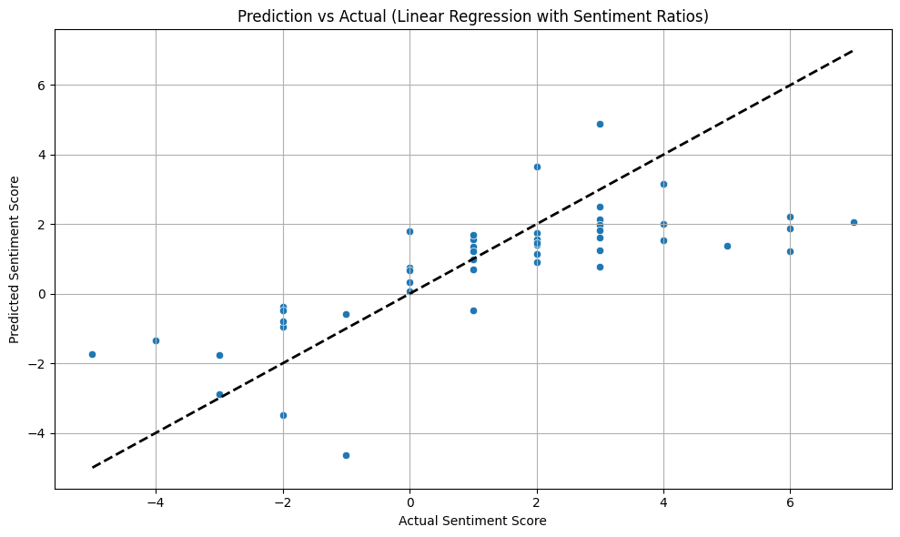

```
Model Coefficients:
                 Feature  Coefficient
0          message_count     0.066972
1            total_words     0.023058
2     avg_message_length    -0.071710
3            total_chars    -0.003851
4  avg_chars_per_message     0.026659
5      words_per_message    -0.071710
6         chars_per_word    -0.126566
7         positive_ratio     4.185315
8          neutral_ratio    -0.418745
9         negative_ratio    -3.766570

Model Evaluation Metrics:
               Metric     Value
0            R2 Score  0.485552
1  Mean Squared Error  3.647353
```

```python
# Load labeled dataset
df_labeled = pd.read_csv("Final_sentiment.csv")
df_labeled["date"] = pd.to_datetime(df_labeled["date"])
df_labeled["month"] = df_labeled["date"].dt.to_period("M")

# Feature Engineering
df_labeled["message_length"] = df_labeled["body"].apply(lambda x: len(str(x).split()))
df_labeled["char_count"] = df_labeled["body"].apply(lambda x: len(str(x)))
df_labeled["words_per_message"] = df_labeled["message_length"]
df_labeled["chars_per_word"] = df_labeled["char_count"] / df_labeled["message_length"].replace(0, 1)

# Monthly Aggregation
monthly_data = df_labeled.groupby(["from", "month"]).agg(
    message_count=("body", "count"),
    total_words=("message_length", "sum"),
    avg_message_length=("message_length", "mean"),
    total_chars=("char_count", "sum"),
    avg_chars_per_message=("char_count", "mean"),
    sentiment_score=("Final_sentiment", lambda x: sum(
        1 if s == "Positive" else -1 if s == "Negative" else 0 for s in x)),
    words_per_message=("words_per_message", "mean"),
    chars_per_word=("chars_per_word", "mean")
).reset_index()

# Sentiment Ratios per Month per Employee
sentiment_counts = df_labeled.pivot_table(
    index=["from", "month"],
    columns="Final_sentiment",
    values="body",
    aggfunc="count",
    fill_value=0
).reset_index()

sentiment_counts["total"] = sentiment_counts[["Positive", "Neutral", "Negative"]].sum(axis=1)
sentiment_counts["positive_ratio"] = sentiment_counts["Positive"] / sentiment_counts["total"]
sentiment_counts["neutral_ratio"] = sentiment_counts["Neutral"] / sentiment_counts["total"]
sentiment_counts["negative_ratio"] = sentiment_counts["Negative"] / sentiment_counts["total"]

# Merge sentiment ratios into modeling dataset
model_data = pd.merge(
    monthly_data,
    sentiment_counts[["from", "month", "positive_ratio", "neutral_ratio", "negative_ratio"]],
    on=["from", "month"],
    how="inner"
)

# Define features and target
features = [
    "message_count", "total_words", "avg_message_length",
    "total_chars", "avg_chars_per_message",
    "words_per_message", "chars_per_word",
    "positive_ratio", "neutral_ratio", "negative_ratio"
]
X = model_data[features].replace([float("inf"), -float("inf")], 0).fillna(0)
y = model_data["sentiment_score"]

# Split into training and test sets
X_train, X_test, y_train, y_test = train_test_split(X, y, test_size=0.2, random_state=42)

# Train Linear Regression Model
model = LinearRegression()
model.fit(X_train, y_train)
y_pred = model.predict(X_test)

# Evaluate Model
mse = mean_squared_error(y_test, y_pred)
r2 = r2_score(y_test, y_pred)

# Visualize Actual vs Predicted Sentiment Scores
plt.figure(figsize=(10, 6))
sns.scatterplot(x=y_test, y=y_pred)
plt.plot([y_test.min(), y_test.max()], [y_test.min(), y_test.max()], 'k--', lw=2)
plt.title("Prediction vs Actual (Linear Regression with Sentiment Ratios)")
plt.xlabel("Actual Sentiment Score")
plt.ylabel("Predicted Sentiment Score")
plt.grid(True)
plt.tight_layout()
plt.show()

# Output Model Coefficients and Evaluation
model_summary = pd.DataFrame({
    "Feature": features,
    "Coefficient": model.coef_
})
print("Model Coefficients:")
print(model_summary)

model_metrics = pd.DataFrame({
    "Metric": ["R2 Score", "Mean Squared Error"],
    "Value": [r2, mse]
})
print("\nModel Evaluation Metrics:")
print(model_metrics)
```

## **Conclusion and Insights**

Across the employee messages, our hybrid sentiment-labeling approach revealed that team members express clear positive or negative tones far more often than neutral ones, underscoring the value of tracking morale explicitly rather than treating ambivalence as the norm. Positive communications slightly outnumber negatives overall, but both fluctuate month to month, with occasional spikes in neutral (informational) messages highlighting shifts in operational focus.

Month-by-month scoring surfaced distinct “mood cycles.” Some employees (e.g., Eric Bass in late 2010) delivered sustained positivity, while others (e.g., Bobette Riner’s sharp dip in August 2010) showed concentrated frustration. These time-based profiles allow managers to pinpoint periods of high enthusiasm for best-practice reinforcement, or intervene when negativity clusters emerge.

Finally, our linear regression model—dominated by positive and negative sentiment ratios—explained nearly half of the variation in monthly mood scores (R²≈0.49). While effective at capturing general trends, it underestimates extreme swings, indicating that incorporating interaction terms, nonlinear techniques, or external covariates (e.g., workload metrics or project milestones) could enhance predictive fidelity.

```python
!jupyter nbconvert "/content/FinalLLMAssessment_v2_0.ipynb" --to html
```

```
[NbConvertApp] Converting notebook /content/FinalLLMAssessment_v2_0.ipynb to html
[NbConvertApp] WARNING | Alternative text is missing on 8 image(s).
[NbConvertApp] Writing 1005786 bytes to /content/FinalLLMAssessment_v2_0.html
```